# Project 4 College Majors and Clustering

The object of this project is to work with a dataset of college majors and their corresponding statistics. The goal is to perform clustering on the data to identify groups of similar majors based on their characteristics. The project will involve data preparation, clustering, and visualization of the results.

The dataset being used in the project is from the [FiveThirtyEight College Majors Dataset](https://www.kaggle.com/datasets/fivethirtyeight/fivethirtyeight-college-majors-dataset) on Kaggle and contains information about the employment and salary statistics of various college majors. For the scope of this project I will specifically be using the `all-ages.csv` dataset to evaluate clusters of college majors based on their economic and employment metrics. By grouping similar fields and or categories to see which fields have common outcomes across all age groups.

The dataset includes the following columns:

- `Major_code`: The code assigned to the major.
- `Major`: The name of the major.
- `Total`: The total number of people employed in the major.
- `Employed`: The number of people employed in the major.
- `Unemployed`: The number of people unemployed in the major.
- `Employed_full_time_year_round`: The number of people employed full-time year-round in the major.
- `Median`: The median salary of people in the major.
- `P25th`: The 25th percentile salary of people in the major.
- `P75th`: The 75th percentile salary of people in the major.
- `Sample_size`: The sample size of the data for the major.
- `Major_category`: The category of the major.

## Overall Problem

The overall problem is to identify clusters of college majors based on their employment and salary statistics. By clustering the majors, we can gain insights into which majors have similar outcomes and characteristics. This can help students and educators understand the job market and make informed decisions about their education and career paths.

The overall questions to be solved are:

1. What are the clusters of college majors based on their employment and salary statistics? (overall question)
2. How do the clusters relate to each other?
3. What insights can be gained from the clustering analysis?
4. How can the clusters be visualized to aid in understanding the data?

# Importing Libraries and Dependencies

```python
import pandas as pd
import matplotlib.pyplot as plt
import seaborn as sns
from sklearn.preprocessing import StandardScaler
from sklearn.cluster import KMeans
from sklearn.metrics import silhouette_score
import scipy.cluster.hierarchy as shc
from sklearn.decomposition import PCA
```

# Loading the Dataset

```python
df = pd.read_csv('data/all-ages.csv')
print(df)
```

```
     Major_code                                            Major  \
0          1100                              GENERAL AGRICULTURE
1          1101            AGRICULTURE PRODUCTION AND MANAGEMENT
2          1102                           AGRICULTURAL ECONOMICS
3          1103                                  ANIMAL SCIENCES
4          1104                                     FOOD SCIENCE
..          ...                                              ...
168        6211                           HOSPITALITY MANAGEMENT
169        6212    MANAGEMENT INFORMATION SYSTEMS AND STATISTICS
170        6299  MISCELLANEOUS BUSINESS & MEDICAL ADMINISTRATION
171        6402                                          HISTORY
172        6403                            UNITED STATES HISTORY

                      Major_category   Total  Employed  \
0    Agriculture & Natural Resources  128148     90245
```

[output cut: 38 more lines]

## Data Preparation and Preprocessing

Before analyzing the data, we need to prepare it by cleaning and preprocessing it. This includes handling missing values, scaling the data, and selecting relevant features for clustering. The first step is to check for any missing values within the dataset, and drop the missing values. The next step was to gather all the features needed for clustering. After gathering the features, the cluster DataFrame was then created and missing values were dropped from that dataframe. The next step was to scale the data using the StandardScaler, which helps to normalize the data making it easier for clustering. Lastly, the scaled data was then converted back into a DataFrame for further analysis.

```python
missing_values = df.isnull().sum()
print("Missing values in each column:")
print(missing_values)

features = ["Employed", "Unemployed", "Total", "Employed_full_time_year_round", "Median", "P25th", "P75th",]

df_cluster = df[features].dropna()

scaler = StandardScaler()
scaled_data = scaler.fit_transform(df_cluster)

df_scaled = pd.DataFrame(scaled_data, columns=features)

df_cluster.head()
```

```
Missing values in each column:
Major_code                       0
Major                            0
Major_category                   0
Total                            0
Employed                         0
Employed_full_time_year_round    0
Unemployed                       0
Unemployment_rate                0
Median                           0
P25th                            0
P75th                            0
dtype: int64
```

|  | Employed | Unemployed | Total | Employed_full_time_year_round | Median | P25th | P75th |
| --- | --- | --- | --- | --- | --- | --- | --- |
| 0 | 90245 | 2423 | 128148 | 74078 | 50000 | 34000 | 80000.0 |
| 1 | 76865 | 2266 | 95326 | 64240 | 54000 | 36000 | 80000.0 |
| 2 | 26321 | 821 | 33955 | 22810 | 63000 | 40000 | 98000.0 |
| 3 | 81177 | 3619 | 103549 | 64937 | 46000 | 30000 | 72000.0 |
| 4 | 17281 | 894 | 24280 | 12722 | 62000 | 38500 | 90000.0 |

# Explanation of Clustering

[Clustering](https://scikit-learn.org/stable/modules/clustering.html) is a form of unsupervised machine learning algorithm used to group similar data points together based on their features. The goal of clustering is to identify natural groupings within the dataset.

There are several types of clustering algorithms, where the ones we will focus on for this dataset include:

1. **K-Means Clustering**: The algorithm partitions the data into a predefined number of clusters `K`. This iteratively assigns each data point to the nearest cluster center and then updates the centers based on the means of the data points within each cluster.
2. **Agglomerate Clustering**: This is a type of hierarchical clustering that starts with each data point as its own cluster and then iteratively merges the closest clusters until a stopping criterion is met. The result is a hierarchy of clusters that can be visualized using a dendrogram.
3. **PCA**: *Principal Component Analysis* is a dimensionality reduction technique that transforms the data into a new coordinate system, where the axes (principal components) are ordered by the amount of variance they explain. PCA is often used to visualize high-dimensional data in lower dimensions (e.g., 2D or 3D) while preserving as much information as possible.

Clustering overall helps to understand the overall structure of data, identify natural patterns, and helps make informed decisions based on the grouping of data. An example, within this context could help us reveal which college majors have similar employment and salary statistics.

# Data Understanding and Visualization

Before diving into immediate clustering, we will create some base visualizations to understand the data better.

## Distribution of Scaled Features

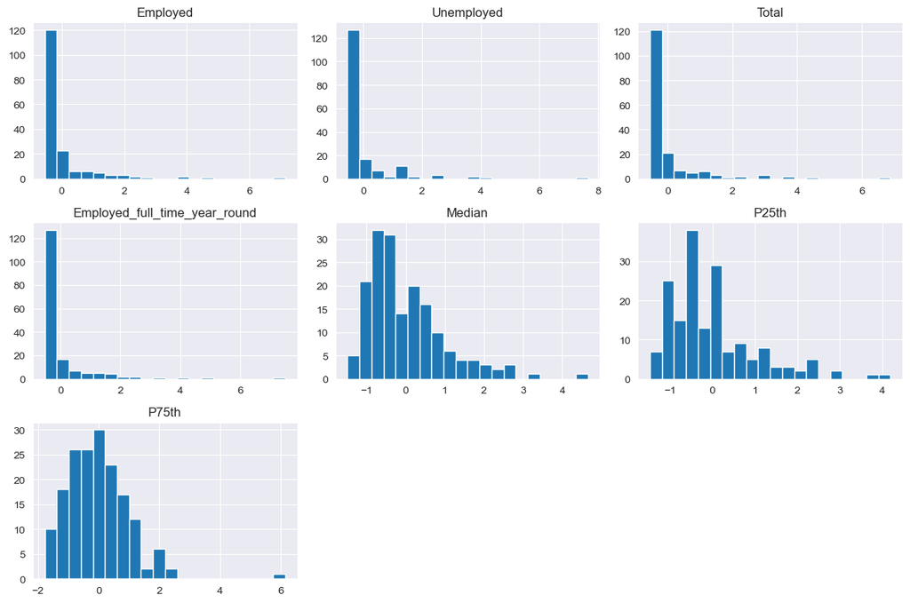

```python
plt.figure(figsize=(12, 8))
df_scaled.hist(bins=20, figsize=(12, 8), layout=(3, 3))
plt.tight_layout()
plt.title("Distribution of Scaled Features")
plt.show()
```

## Correlation Matrix

The correlation matrix shares a heatmap of the relationship between different features within the dataset. A key observation of the correlation matrix is:

- Strong positive correlations between employed and the total, indicating that majors with more employed individuals tend to have a higher total number of individuals in that major overall

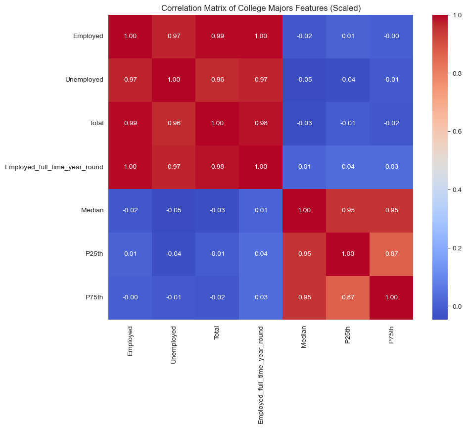

```python
corr_matrix = df_scaled.corr()

plt.figure(figsize=(10, 8))
sns.heatmap(corr_matrix, annot=True, cmap='coolwarm', fmt=".2f", square=True)
plt.title("Correlation Matrix of College Majors Features (Scaled)")
plt.show()
```

## K-Means Clustering

K-means was chosen as the first clustering algorithm due to its simplicity and efficiency in handling large datasets. It is a widely used algorithm for clustering tasks and provides a good starting point for understanding the data while also letting us know the optimal number of clusters.

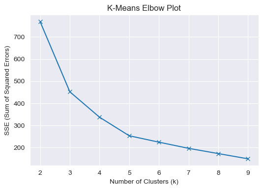

```python
sse = []
K_range = range(2, 10)
for k in K_range:
    kmeans = KMeans(n_clusters=k, random_state=42)
    kmeans.fit(df_scaled)
    sse.append(kmeans.inertia_)

plt.figure(figsize=(6, 4))
plt.plot(K_range, sse, marker='x')
plt.title("K-Means Elbow Plot")
plt.xlabel("Number of Clusters (k)")
plt.ylabel("SSE (Sum of Squared Errors)")
plt.show()
```

## K-Means Clustering with Optimal Clusters

The next step is to perform K-Means clustering with the optimal number of clusters determined from the elbow plot which was 4. The [silhouette score](https://scikit-learn.org/stable/auto_examples/cluster/plot_kmeans_silhouette_analysis.html) is then calculated to evaluate the quality of the clustering. The silhouette score ranges from -1 to 1, where a higher score indicates better-defined clusters. The silhouette score for the optimal number of clusters is printed below. The clusters are then added to the original DataFrame for further analysis. From this analysis, it seems the score was 0.499, which indicates a fair clustering of the dataset.

```python
k_opt = 4
kmeans = KMeans(n_clusters=k_opt, random_state=42)
kmeans_labels = kmeans.fit_predict(df_scaled)


kmeans_silhouette = silhouette_score(df_scaled, kmeans_labels)
print(f"K-Means Silhouette Score (k={k_opt}): {kmeans_silhouette:.3f}")

df_cluster['KMeans_Cluster'] = kmeans_labels
```

```
K-Means Silhouette Score (k=4): 0.499
```

## Truncated Dendrogram

This part deals with visualization of a hierarchical clustering using a [dendrogram](https://www.displayr.com/what-is-dendrogram/). The dendrogram is a tree-like diagram that records the sequences of merges or slits. The dendrogram below is truncated to show up to the last 12 merges to showcase a better visualization. Truncating in this case helps simplify the visualization, making it easier to read and interpret.

The dendrogram is created using the [Ward's method](https://online.stat.psu.edu/stat505/lesson/14/14.7), which minimizes the variance within each cluster. The x-axis represents the cluster size, and the y-axis represents the distance or dissimilar between clusters.

An observation made from this dendrogram is that there are 4 main clusters that can be identified, which aligns with the K-Means clustering results. The dendrogram also shows the hierarchical structure of the clusters, which can be useful for understanding the relationships between different clusters.

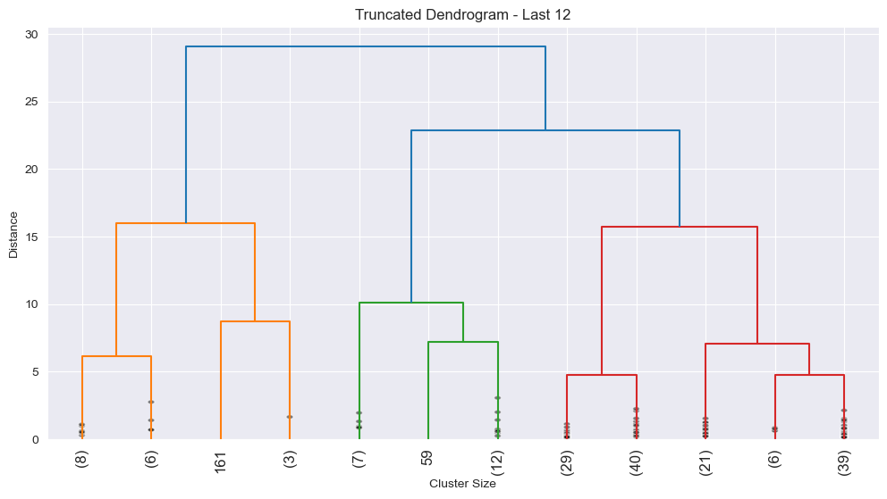

```python
plt.figure(figsize=(12, 6))
shc.dendrogram(
    shc.linkage(df_scaled, method='ward'),
    truncate_mode='lastp',
    p=12,
    leaf_rotation=90,
    leaf_font_size=12,
    show_contracted=True
)
plt.title("Truncated Dendrogram - Last 12")
plt.xlabel("Cluster Size")
plt.ylabel("Distance")
plt.show()
```

## Full Dendrogram with Distance Threshold

For this part, we have the comparison to the full dendrogram with a distance threshold. The distance threshold is set to 6, which helps to identify the clusters more clearly. The red-dashed line indicates the distance threshold, and the clusters are formed based on this threshold. The dendrogram shows the hierarchical structure of the clusters, and the distance threshold helps to identify the clusters more clearly.

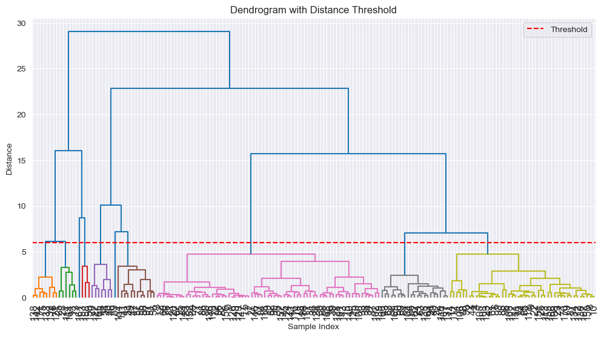

```python
plt.figure(figsize=(12, 6))
ddata = shc.linkage(df_scaled, method='ward')
shc.dendrogram(
    ddata,
    color_threshold=6,
    leaf_rotation=90,
    leaf_font_size=12,
    show_contracted=True
)
plt.axhline(y=6, color='r', linestyle='--', label="Threshold")
plt.title("Dendrogram with Distance Threshold")
plt.xlabel("Sample Index")
plt.ylabel("Distance")
plt.legend()
plt.show()
```

## Salary Box Plot

The box plot below shows the distribution of median salaries for each cluster. The box plot provides a visual representation of the median salary distribution for each cluster, including the median, quartiles, and potential outliers. The box plot helps to identify the differences in median salaries between the clusters.

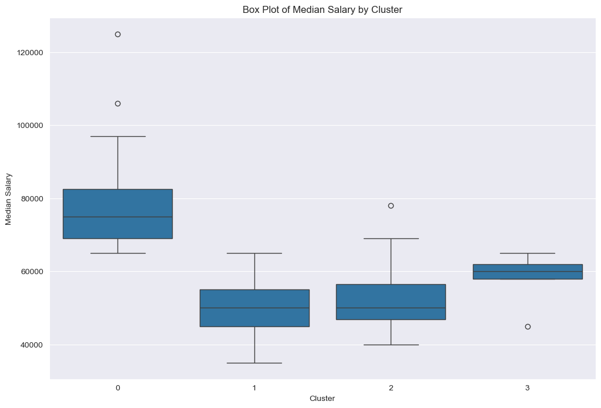

```python
plt.figure(figsize=(12, 8))
sns.boxplot(x='KMeans_Cluster', y='Median', data=df_cluster)
plt.title("Box Plot of Median Salary by Cluster")
plt.xlabel("Cluster")
plt.ylabel("Median Salary")
plt.show()
```

## PCA (Principal Component Analysis)

PCA was picked as the ue due to its simplicity and effectiveness in reducing the dimensionality of the dataset while preserving the variance. PCA is widely used in data analysis and visualization, making it a fair choice for this project.

From this we observed that the first two principal parts explain the variance in the data, which is a good amount of variance to capture for visualization purposes.

```python
pca = PCA(n_components=2)
pca_result = pca.fit_transform(df_scaled)

pca_df = pd.DataFrame(data=pca_result, columns=['PC1', 'PC2'])

print(f"Explained Variance Ratio: PC1 = {pca.explained_variance_ratio_[0]*100:.1f}%, PC2 = {pca.explained_variance_ratio_[1]*100:.1f}%")
```

```
Explained Variance Ratio: PC1 = 56.3%, PC2 = 40.7%
```

## PCA Scatter Plot

The PCA scatter plot shows that the clusters are somewhat separated, indicating that the K-Means clustering algorithm performed well. The scatterplot additionally shows that most of the points are to the left of the principal components, indicating that most of the majors have lower employment and salary statistics.

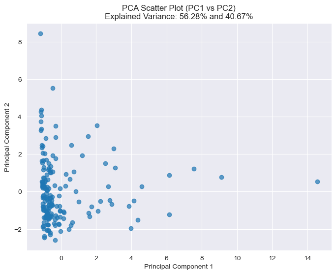

```python
plt.figure(figsize=(8, 6))
plt.scatter(pca_df['PC1'], pca_df['PC2'], alpha=0.7)
plt.title(f"PCA Scatter Plot (PC1 vs PC2)\nExplained Variance: {pca.explained_variance_ratio_[0]*100:.2f}% and {pca.explained_variance_ratio_[1]*100:.2f}%")
plt.xlabel("Principal Component 1")
plt.ylabel("Principal Component 2")
plt.grid(True)
plt.show()
```

## PCA Scatter Plot with reduced PCA data

*The clusters are color-coded based on the K-Means clustering results.*

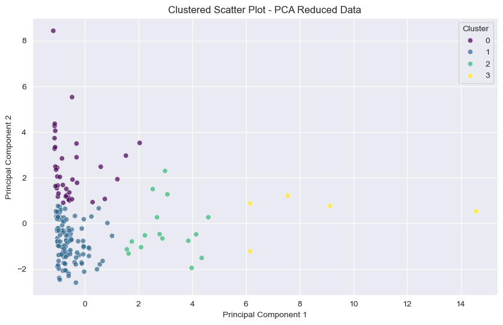

```python
plt.figure(figsize=(10, 6))
sns.scatterplot(x=pca_df['PC1'], y=pca_df['PC2'], hue=df_cluster['KMeans_Cluster'], palette='viridis', alpha=0.7)
plt.title("Clustered Scatter Plot - PCA Reduced Data")
plt.xlabel("Principal Component 1")
plt.ylabel("Principal Component 2")
plt.legend(title='Cluster')
plt.grid(True)
plt.show()
```

## Heatmap of Cluster Centers

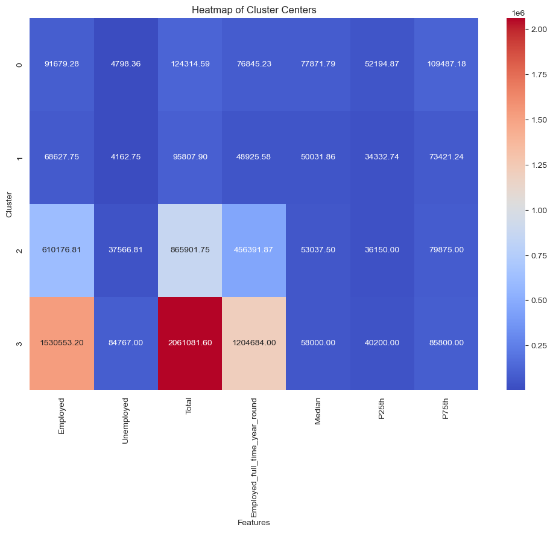

```python
cluster_centers = scaler.inverse_transform(kmeans.cluster_centers_)
cluster_centers_df = pd.DataFrame(cluster_centers, columns=features)

plt.figure(figsize=(12, 8))
sns.heatmap(cluster_centers_df, annot=True, cmap='coolwarm', fmt=".2f")
plt.title("Heatmap of Cluster Centers")
plt.xlabel("Features")
plt.ylabel("Cluster")
plt.show()
```

## Information Regarding the Majors

This step helps answer the key question of breaking down which majors fit into the categories. The majors are grouped by their respective clusters, and the most common majors within each cluster are identified. This information helps to understand the characteristics of each cluster and the majors that belong to them. The most common majors within each cluster are printed below. It seems that the first clusters have the highest group of majors, while the bottom group of clusters have the least number of majors.

In order to display the different major groups, the features were grouped by the KMeans cluster and the major category, then the most common majors were identified within each cluster. Then, after fitting the data into the scalar and using the same number of optimal k points, the majors are listed below.

```python
features = ["Major", "Employed", "Unemployed", "Total", "Employed_full_time_year_round", "Median", "P25th", "P75th", "Major_category"]

df_cluster2 = df[features].dropna()

scaler = StandardScaler()
scaled_data = scaler.fit_transform(df_cluster2.drop(columns=['Major', 'Major_category']))

df_scaled = pd.DataFrame(scaled_data, columns=features[1:-1])
df_scaled['Major'] = df_cluster2['Major'].values

k_opt = 4
kmeans = KMeans(n_clusters=k_opt, random_state=42)
kmeans_labels = kmeans.fit_predict(df_scaled.drop(columns=['Major']))

df_cluster2['KMeans_Cluster'] = kmeans_labels


clusters = df_cluster2.groupby('KMeans_Cluster')['Major'].apply(list).reset_index()

for index, row in clusters.iterrows():
    print(f"Cluster {row['KMeans_Cluster']}:")
    for major in row['Major']:
        print(f" - {major}")
    print("\n")
```

```
Cluster 0:
 - COMPUTER AND INFORMATION SYSTEMS
 - INFORMATION SCIENCES
 - GENERAL ENGINEERING
 - AEROSPACE ENGINEERING
 - ARCHITECTURAL ENGINEERING
 - CHEMICAL ENGINEERING
 - CIVIL ENGINEERING
 - COMPUTER ENGINEERING
 - ELECTRICAL ENGINEERING
 - ENGINEERING MECHANICS PHYSICS AND SCIENCE
 - ENVIRONMENTAL ENGINEERING
 - GEOLOGICAL AND GEOPHYSICAL ENGINEERING
 - INDUSTRIAL AND MANUFACTURING ENGINEERING
 - MATERIALS ENGINEERING AND MATERIALS SCIENCE
 - MECHANICAL ENGINEERING
 - METALLURGICAL ENGINEERING
 - MINING AND MINERAL ENGINEERING
 - NAVAL ARCHITECTURE AND MARINE ENGINEERING
 - NUCLEAR ENGINEERING
 - PETROLEUM ENGINEERING
 - MISCELLANEOUS ENGINEERING
 - ENGINEERING AND INDUSTRIAL MANAGEMENT
 - ELECTRICAL ENGINEERING TECHNOLOGY
 - INDUSTRIAL PRODUCTION TECHNOLOGIES
 - MATHEMATICS
 - APPLIED MATHEMATICS
 - STATISTICS AND DECISION SCIENCE
 - MATHEMATICS AND COMPUTER SCIENCE
 - ASTRONOMY AND ASTROPHYSICS
 - GEOLOGY AND EARTH SCIENCE
 - PHYSICS
 - MATERIALS SCIENCE
 - CONSTRUCTION SERVICES
 - TRANSPORTATION SCIENCES AND TECHNOLOGIES
 - PHARMACY PHARMACEUTICAL SCIENCES AND ADMINISTRATION
 - ACTUARIAL SCIENCE
 - OPERATIONS LOGISTICS AND E-COMMERCE
 - BUSINESS ECONOMICS
 - MANAGEMENT INFORMATION SYSTEMS AND STATISTICS
```

[output cut: 128 more lines]

```
 - POLITICAL SCIENCE AND GOVERNMENT
 - SOCIOLOGY
 - FINE ARTS
 - COMMERCIAL ART AND GRAPHIC DESIGN
 - MARKETING AND MARKETING RESEARCH
 - FINANCE
 - HISTORY


Cluster 3:
 - PSYCHOLOGY
 - NURSING
 - GENERAL BUSINESS
 - ACCOUNTING
 - BUSINESS MANAGEMENT AND ADMINISTRATION
```

## Most Common Majors within Each Cluster

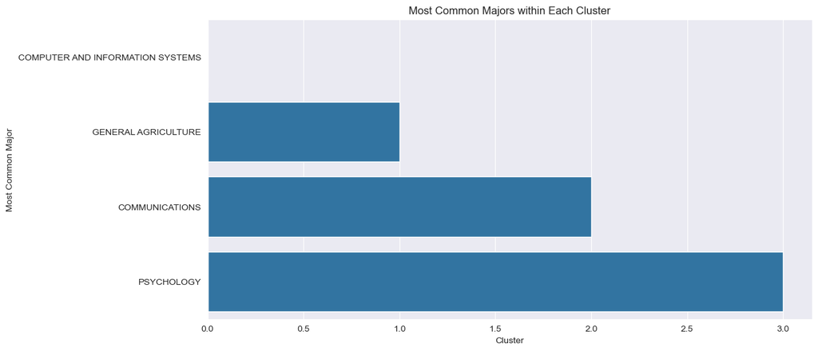

```python
most_common_majors = df_cluster2.groupby('KMeans_Cluster')['Major'].agg(lambda x: x.value_counts().index[0]).reset_index()

plt.figure(figsize=(12, 6))
sns.barplot(x='KMeans_Cluster', y='Major', data=most_common_majors)
plt.title("Most Common Majors within Each Cluster")
plt.xlabel("Cluster")
plt.ylabel("Most Common Major")
plt.show()
```

## Distribution of Majors within Each Category Group by Cluster

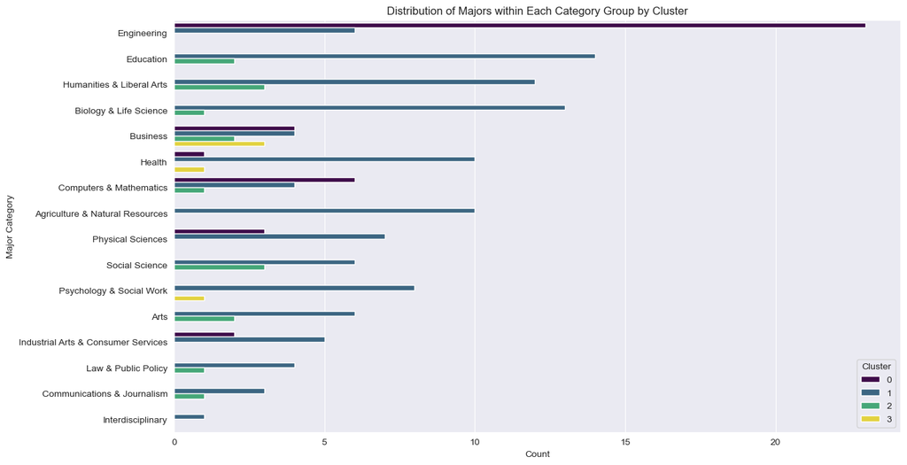

```python
plt.figure(figsize=(14, 8))
sns.countplot(y='Major_category', hue='KMeans_Cluster', data=df_cluster2, palette='viridis', order=df_cluster2['Major_category'].value_counts().index)
plt.title("Distribution of Majors within Each Category Group by Cluster")
plt.xlabel("Count")
plt.ylabel("Major Category")
plt.legend(title='Cluster')
plt.show()
```

## Clustering Analysis

Regarding clustering analysis overall, the K-Means clustering algorithm performed well in identifying the clusters within the dataset. The elbow method and silhouette score helped to determine the optimal number of clusters, and the dendrogram provided a hierarchical view of the clusters. The PCA scatter plot helped to visualize the clustering results in a lower-dimensional space, and the heatmap of cluster centers provided a visual representation of the differences between the clusters.

# Impact

The clustering analysis of college majors based on employment and salary statistics can have several potential impacts:

## Social Impact

The social impact of this project can help impact decision-making where students can make informed decisions about their education and career paths by providing insights into the economic outcomes of different majors. This can help lead to better alignment between education and workforce needs. Additionally, the analysis can help identify potential disparities in employment and salary outcomes among different majors, which can inform discussions about equity and access to education.

#### Ethical Impact

Regarding the ethical impact, the project raises several important considerations:

1. Bias and Fairness: Some conclusions from this dataset can help reinforce existing biases or stereotypes about certain majors or fields of study. For example, majors historically associated with lower employment rates or salaries may be unfairly stigmatized, leading to negative perceptions of those fields.
2. Access to Information: Another possible impact could be the access to information. The analysis can help provide valuable information to students and educators, but it is important to ensure that this information is accessible to all individuals, regardless of their background or socioeconomic status. This can help level the playing field and provide more opportunities for all students to make informed decisions.

## Economic Impact

Regarding the economic impact, the clustering analysis can help with identifying which majors have better employment and salary outcomes, which can help in aligning the demands of the market. Additionally, the analysis from the project can help inform educational institutions and policymakers about the economic outcomes of different majors, which can help guide decisions about program offerings and funding.

## Negative Impacts

1. The analysis focuses primarily on economic outcomes, which may lead to overemphasis on certain majors at the expense of others. This can discourage students from pursuing majors that may not have the highest economic returns but are still valuable for personal growth and development.
2. The analysis primary considers economic outcomes, which may overshadow other important factors such as overall job satisfaction, work-life balance, and other areas where people could be moved to pick a certain field.

Overall, while the clustering analysis provides valuable insights into mainly economic outcomes for different college majors. It is important to consider the broader social, ethical, and economic implications of the analysis and ensure that the findings are used responsibly and ethically.

# References

- FiveThirtyEight. (n.d.). *FiveThirtyEight College Majors Dataset*. Kaggle. Retrieved from https://www.kaggle.com/datasets/fivethirtyeight/fivethirtyeight-college-majors-dataset
- scikit-learn. (n.d.). *Clustering*. Retrieved from https://scikit-learn.org/stable/modules/clustering.html
- Displayr. (n.d.). *What is Dendrogram?*. Retrieved from https://www.displayr.com/what-is-dendrogram/
- Penn State Eberly College of Science. (n.d.). *Ward's method*. Retrieved from https://online.stat.psu.edu/stat505/lesson/14/14.7
- scikit-learn. (n.d.). *Silhouette Score*. Retrieved from https://scikit-learn.org/stable/auto_examples/cluster/plot_kmeans_silhouette_analysis.html
- scikit-learn. (n.d.). *PCA*. Retrieved from https://scikit-learn.org/stable/modules/generated/sklearn.decomposition.PCA.html
- scikit-learn. (n.d.). *StandardScaler*. Retrieved from https://scikit-learn.org/stable/modules/generated/sklearn.preprocessing.StandardScaler.html
- scikit-learn. (n.d.). *Agglomerative Clustering*. Retrieved from https://scikit-learn.org/stable/modules/generated/sklearn.cluster.AgglomerativeClustering.html
- scikit-learn. (n.d.). *KMeans*. Retrieved from https://scikit-learn.org/stable/modules/generated/sklearn.cluster.KMeans.html

# Code

The notebook file can be found at the following link: https://github.com/ToyaOkey/Project4